# TensorFlow Linear Classifier

Joseph Rickert

In this notebook, we use functions from the `tfestimators` package and the TensorFlow `Estimator` API to build a linear classifier.

## Prepare the Data

The `titanic_train` dataset from R’s titanic package contains 12 fields of information on 891 passengers from the Titanic. In this example we load `titanic_train` into `TensorFlow` and fit a linear classifier model in `TensorFlow` using the function `tfestimators::linear_classifier()`.

```r
#devtools::install_github("rstudio/tfestimators")
library(tfestimators)
library(tensorflow)
library(tidyverse)
library(titanic)
head(titanic_train)
```

|  | PassengerId | Survived | Pclass | Name | Sex | Age | SibSp | Parch | Ticket | Fare | Cabin | Embarked |
| --- | --- | --- | --- | --- | --- | --- | --- | --- | --- | --- | --- | --- |
| 1 | 1 | 0 | 3 | Braund, Mr. Owen Harris | male | 22 | 1 | 0 | A/5 21171 | 7.2500 |  | S |
| 2 | 2 | 1 | 1 | Cumings, Mrs. John Bradley (Florence Briggs Thayer) | female | 38 | 1 | 0 | PC 17599 | 71.2833 | C85 | C |
| 3 | 3 | 1 | 3 | Heikkinen, Miss. Laina | female | 26 | 0 | 0 | STON/O2. 3101282 | 7.9250 |  | S |
| 4 | 4 | 1 | 1 | Futrelle, Mrs. Jacques Heath (Lily May Peel) | female | 35 | 1 | 0 | 113803 | 53.1000 | C123 | S |
| 5 | 5 | 0 | 3 | Allen, Mr. William Henry | male | 35 | 0 | 0 | 373450 | 8.0500 |  | S |
| 6 | 6 | 0 | 3 | Moran, Mr. James | male | NA | 0 | 0 | 330877 | 8.4583 |  | Q |

Load the data into TensorFlow and have a look.

```r
titanic_set <- titanic_train %>%
  filter(!is.na(Age))
glimpse(titanic_set)
```

```
Observations: 714
Variables: 12
$ PassengerId <int> 1, 2, 3, 4, 5, 7, 8, 9, 10, 11, 12, 13, 14, 15, 16, 17, 19, 21, 22, 23, ...
$ Survived    <int> 0, 1, 1, 1, 0, 0, 0, 1, 1, 1, 1, 0, 0, 0, 1, 0, 0, 0, 1, 1, 1, 0, 1, 0, ...
$ Pclass      <int> 3, 1, 3, 1, 3, 1, 3, 3, 2, 3, 1, 3, 3, 3, 2, 3, 3, 2, 2, 3, 1, 3, 3, 1, ...
$ Name        <chr> "Braund, Mr. Owen Harris", "Cumings, Mrs. John Bradley (Florence Briggs ...
$ Sex         <chr> "male", "female", "female", "female", "male", "male", "male", "female", ...
$ Age         <dbl> 22, 38, 26, 35, 35, 54, 2, 27, 14, 4, 58, 20, 39, 14, 55, 2, 31, 35, 34,...
$ SibSp       <int> 1, 1, 0, 1, 0, 0, 3, 0, 1, 1, 0, 0, 1, 0, 0, 4, 1, 0, 0, 0, 0, 3, 1, 3, ...
$ Parch       <int> 0, 0, 0, 0, 0, 0, 1, 2, 0, 1, 0, 0, 5, 0, 0, 1, 0, 0, 0, 0, 0, 1, 5, 2, ...
$ Ticket      <chr> "A/5 21171", "PC 17599", "STON/O2. 3101282", "113803", "373450", "17463"...
$ Fare        <dbl> 7.2500, 71.2833, 7.9250, 53.1000, 8.0500, 51.8625, 21.0750, 11.1333, 30....
$ Cabin       <chr> "", "C85", "", "C123", "", "E46", "", "", "", "G6", "C103", "", "", "", ...
$ Embarked    <chr> "S", "C", "S", "S", "S", "S", "S", "S", "C", "S", "S", "S", "S", "S", "S...
```

Notice that both `Sex` and `Embarked` are character variables. We would like to make both of these categorical variables for the analysis. This is done with the `tfestimators::feature_columns()` function. Category levels are set by passing a list to the `vocabulary_list argument`. The Pclass variable is passed as a numeric feature, so there no further definition.

```r
cols <- feature_columns(
  column_categorical_with_vocabulary_list("Sex", vocabulary_list =
                                            list("male", "female")),
  column_categorical_with_vocabulary_list("Embarked", vocabulary_list =
                                            list("S", "C", "Q", "")),
  column_numeric("Pclass")
)
```

## Build the Model

The first step in building the model is to use the `tfestimators::linear_classifier()` function to build the TensorFlow model object. After that, we use the `tfestimators::input_fn()` to define enter the predictive variables and response variable for the classifier. We are trying to predict survival from knowing a passenger’s sex, ticket class and port of embarkation.

```r
model <- linear_classifier(feature_columns = cols)
titanic_input_fn <- function(data) {
  input_fn(data,
           features = c("Sex", "Pclass", "Embarked"),
           response = "Survived")
}
```

We complete the setup by splitting the data into training and test data sets.

```r
indices <- sample(1:nrow(titanic_set), size = 0.80 * nrow(titanic_set))
train <- titanic_set[indices, ]
test  <- titanic_set[-indices, ]
```

## Fit the Model

```r
train(model, titanic_input_fn(train))
```

```
[-] Training -- loss: 88.72, step: 1
[\] Training -- loss: 80.19, step: 2
[|] Training -- loss: 73.52, step: 3
[/] Training -- loss: 70.46, step: 4
[-] Training -- loss: 33.85, step: 5
```

Look at the model files that have been written to disk.

```r
list.files(model$estimator$model_dir)
```

```
[1] "checkpoint"
[2] "graph.pbtxt"
[3] "logs"
[4] "model.ckpt-1.data-00000-of-00001"
[5] "model.ckpt-1.index"
[6] "model.ckpt-1.meta"
[7] "model.ckpt-5.data-00000-of-00001"
[8] "model.ckpt-5.index"
[9] "model.ckpt-5.meta"
```

Look at the model coefficients.

```r
coef(model)
```

```
$global_step
[1] 5

$`linear/linear_model/Embarked/weights`
           [,1]
[1,] -0.0894402
[2,]  0.5838472
[3,] -0.1285219
[4,]  0.0000000

$`linear/linear_model/Embarked/weights/part_0/Ftrl`
           [,1]
[1,] 209.573700
[2,]  33.511112
[3,]   2.069724
[4,]   0.100000

$`linear/linear_model/Embarked/weights/part_0/Ftrl_1`
            [,1]
[1,]   6.4739766
[2,] -16.8991032
[3,]   0.9244921
[4,]   0.0000000

$`linear/linear_model/Pclass/weights`
           [,1]
[1,] -0.2048631

$`linear/linear_model/Pclass/weights/part_0/Ftrl`
         [,1]
[1,] 2630.524

$`linear/linear_model/Pclass/weights/part_0/Ftrl_1`
         [,1]
[1,] 52.53573

$`linear/linear_model/Sex/weights`
           [,1]
[1,] -0.4201415
[2,]  0.5729303

$`linear/linear_model/Sex/weights/part_0/Ftrl`
         [,1]
[1,] 621.8146
[2,] 682.7690

$`linear/linear_model/Sex/weights/part_0/Ftrl_1`
          [,1]
[1,]  52.38369
[2,] -74.85291

$`linear/linear_model/bias_weights`
[1] 0.008847036

$`linear/linear_model/bias_weights/part_0/Ftrl`
[1] 292.0897

$`linear/linear_model/bias_weights/part_0/Ftrl_1`
[1] -0.7560072
```

## Evaluate the Model

The `tensorflow::evaluate()` function tests the model’s performance. Note that it will adds a sub-folder called `eval` the model’s folder.

```r
model_eval <- evaluate(model, titanic_input_fn(test))
```

```
WARNING:tensorflow:Casting <dtype: 'float32'> labels to bool.
WARNING:tensorflow:Casting <dtype: 'float32'> labels to bool.
```

```
[-] Evaluating -- loss: 62.98, step: 1

[\] Evaluating -- loss: 9.60, step: 2
```

Next, we use some `tidyverse` code to format the results of the model.

```r
model_eval %>%
  flatten() %>%
  as_tibble() %>%
  glimpse()
```

```
Observations: 1
Variables: 9
$ loss                 <dbl> 39.06967
$ accuracy_baseline    <dbl> 0.5734266
$ global_step          <dbl> 5
$ auc                  <dbl> 0.8216714
$ `prediction/mean`    <dbl> 0.3830608
$ `label/mean`         <dbl> 0.4265734
$ average_loss         <dbl> 0.546429
$ auc_precision_recall <dbl> 0.8341089
$ accuracy             <dbl> 0.8181818
```

## Run Predictions with the Model

R’s familiar `predict()` function can be used to make predictions, but notice that the `test` data set needs to be wrapped in the `titanic_input_fn()` we wrote above.

```r
model_predict <- predict(model, titanic_input_fn(test))
```

The following code unpacks the list containing the prediction results.

```r
res <- data.frame(matrix(unlist(model_predict[[1]]),ncol=2,byrow=TRUE),
                  unlist(model_predict[[2]]), unlist(model_predict[[3]]),
                  unlist(model_predict[[4]]), unlist(model_predict[[5]]))
names(res) <- c("Prob Survive", "Prob Perish",names(model_predict)[2:5])
head(res)
```

|  | Prob Survive | Prob Perish | logits | classes | class_ids | logistic |
| --- | --- | --- | --- | --- | --- | --- |
| 1 | 0.7531203 | 0.2468797 | -1.1153239 | 0 | 0 | 0.2468797 |
| 2 | 0.7603146 | 0.2396853 | -1.1544056 | 0 | 0 | 0.2396853 |
| 3 | 0.5305250 | 0.4694750 | -0.1222520 | 0 | 0 | 0.4694750 |
| 4 | 0.3195374 | 0.6804626 | 0.7558985 | 1 | 1 | 0.6804626 |
| 5 | 0.5305250 | 0.4694750 | -0.1222520 | 0 | 0 | 0.4694750 |
| 6 | 0.6087442 | 0.3912558 | -0.4420364 | 0 | 0 | 0.3912558 |

## TensorBoard

Finally, use the [TensorBoard](https://www.tensorflow.org/get_started/summaries_and_tensorboard) visualization tool to look at the model.

```r
tensorboard(model$estimator$model_dir, launch_browser = TRUE)
```

```
TensorBoard 0.4.0rc2 at http://127.0.0.1:6789 (Press CTRL+C to quit)
W1204 19:49:52.143426 Reloader plugin_event_accumulator.py:303] Found more than one graph event per run, or there was a metagraph containing a graph_def, as well as one or more graph events.  Overwriting the graph with the newest event.
W1204 19:49:52.144063 Reloader plugin_event_accumulator.py:311] Found more than one metagraph event per run. Overwriting the metagraph with the newest event.
```

```
Started TensorBoard at http://127.0.0.1:6789
```

Here, is the flow graph for the model calculations.

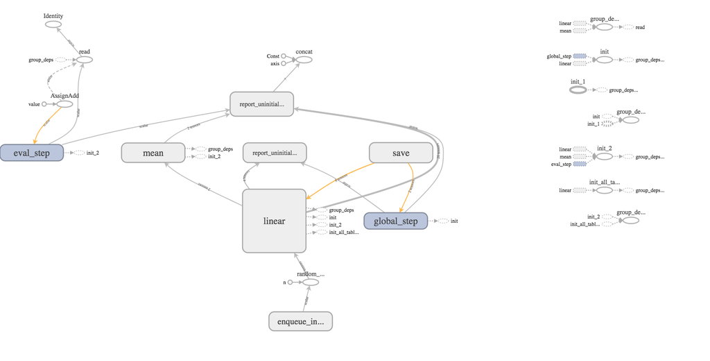